# Analysing the Features Associated With Heart Disease: Cleveland Heart Study

Karthik Sivaram

14th June, 2020

**Click here For Code/Plots**

```r
knitr::opts_chunk$set(out.extra = 'class="plot"')
######################################################################################################################################################################################################
######################################################################################################################################################################################################
##Cleveland Heart Disease Analysis
#Author: Karthik Sivaram
#Date: 10th June 2020
######################################################################################################################################################################################################
######################################################################################################################################################################################################

##Library
library(tidyverse)
library(scales)
library(ggpubr)
library(gmodels)
library(forcats)
library(glmnet)
library(corrplot)
library(gt)
library(paletteer)
library(dichromat)
library(gtsummary)
library(MASS)
library(tidymodels)
library(kableExtra)
library(knitr)
library(vip)
library(ranger)
library(doParallel)
library(car)
####################################################################################################################################################################################
######################################################################################################################################################################################################
##User Defined Functions

#Converting factor to numeric
as.num.fact <- function(x) {as.numeric(as.character(x))}

#Calculate difference in means as a percentage of standard deviation for continuous variables

cont_mean_pct_sd <- function(x){

  when_1 <- mean(final_data[final_data$num == 1, x])

  when_0 <- mean(final_data[final_data$num == 0, x])

  sd_pool     <- sd(final_data[,x])

  return( (when_1 - when_0)*100/sd_pool  )
}

#Calculate p_value for continuous variables

cont_p_value <- function(x){
  t.test(final_data[final_data$num == 1, x], final_data[final_data$num == 0, x])$p.value
}


#Calculate scaled mean for categorical variables
cat_mean_pct_sd <- function(x){

  when_1 <- mean(as.num.fact((filter(final_data,!!as.symbol(x) == 1) %>% dplyr::select(num))$num))

  when_0 <- mean(as.num.fact((filter(final_data,!!as.symbol(x) == 0) %>% dplyr::select(num))$num))

  sd_pool <- sd(as.num.fact(final_data$num ))
  return( (when_1 - when_0)*100/sd_pool  )

}


#P-value for categorical variables
cat_p_value <- function(x){

  return(t.test(as.num.fact((filter(final_data,!!as.symbol(x) == 1) %>% dplyr::select(num))$num) ,  as.num.fact((filter(final_data,!!as.symbol(x) == 0) %>% dplyr::select(num))$num)  )$p.value)
}

#Concordance between two categorical variables

concord_cat <- function(x, y){

  first = final_data[, x]
  second = final_data[, y]
  return(sum(first == second)*100/297)


}

##Remove outlier from a df given a column and return df without outliers

var_remove_outliers <- function(x,df ){

  stage_df <- df

  out <- integer(0)

  if(is.numeric(stage_df[,x])){

    out <- which(abs(stage_df[, x]) >( abs( mean(stage_df[, x])) + abs((3*sd(stage_df[, x])))) )

  }

  if(length(out) > 0){

    stage_df <- stage_df[-out,]
  }
  return(stage_df)


}
##Standardize continuous variables by centering and dividing by 2*SD

var_scale <- function(x){return((x - mean(x))/(2*sd(x)))}


##Normalize a variable
var_norm <- function(x){return((x - mean(x))/(sd(x)))}

######################################################################################################################################################################################################
######################################################################################################################################################################################################
#Part 1: Reading the data

#Setting seed to ensure replicability of results
set.seed(789)

#Reading data

data <- read.csv("processed.cleveland.data", header=FALSE,sep=",",na.strings = '?')

######################################################################################################################################################################################################
######################################################################################################################################################################################################
```

## Introduction

In this notebook I apply different statistical and machine learning techniques to understand the relationship between Coronary Heart Disease and various features assocaited with it using a publicly available dataset. I use the Cleveland Heart Study dataset made available in the [UC Irvine Machine Learning Repository](https://archive.ics.uci.edu/ml/datasets/Heart+Disease).

There are three important caveats regarding the scope of this exercise that I wish to state at the very beginning:

1. Although I apply some techniques that are associated causal inference, it is **not possible** to make a causal claim regarding heart disease using this dataset for two reasons:
- First, the dataset deals with an observational study and not an experimental one. That is there is no randomly assigned treatment variable that we can exploit to estimate an average causal effect.
- Second, I have no domain expertise or specific knowledge of cardiology or for that matter medicine. So I am unable to build a structural casual model using the available features that would allow for estimation of causal relationships.
2. Therefore the scope of this study is strictly restricted to analysing the association relationship in the dataset using my knowledge of statistics and machine learning. Since the dataset comes from a hospital in Cleveland, it maybe safe to assume that it is a representative sample of patients at risk of heart disease. Therefore, the associational claims maybe generalisable to such a population.
3. The larger purpose of this exercise is to demonstrate how statistics and machine learning can be applied for inference and distilling insights from data.

With those caveats in place, I shall proceed as follows. The notebook is divided into three parts. In Part 1, I explore the features in the dataset, pre-process them, and look at naive associational relationships between each feature (independent variables) and the response variable (dependent variable).

## Part 1: Feature Processing and Naive Associational Relationships

In this section, I first remove rows with null values (there are only 6 out of 303) and then I examine each feature in the data set to better understand its meaning, distribution, and association with heart disease. In the dataset there are 9 categorical variables (including the response variable) and 5 continuous variables. In order to simplify the analysis, where reasonably possible I reduce categorical variables with multiple categories to a dichotomous variable without significant loss of information.I begin by applying this to the response variable. Then I look at the naive association between that feature and the response variable. I call this naive in contrast to other analyses because I looks at the relationship without conditioning on other features. This provides a primer for more sophisticated analyses in later sections. At the end of this section, I propose a metric to compare each feature’s relationship to the response variable.

NB: For each feature, I use the definition provided in the data dictionary with the variable name as coded in the dataset in parantheses.

### 1. Diagnosis of Heart Disease (num)

This is the response variable for my analysis. It is categorical variable that takes any of values from 0 to 4. However, the data dictionary only mentions 0 for less than 50% reduction in diameter and 1 for > 50% reduction. Therefore, I convert all values greater than 0 to 1. This can be interpreted as a 1 indicating diagnosis of heart disease and 0 indicating no diagnosis. Below I plot the distribution after processing the variable.

**Click here For Code and Plots**

```r
######################################################################################################################################################################################################
## Cleaning and Naive tests of association of independent variables with Heart Disease outcome

##Adding column names from data dictionary

names(data) <- c( "age", "sex", "cp", "trestbps", "chol","fbs", "restecg",
                        "thalach","exang", "oldpeak","slope", "ca", "thal", "num")

#checking for missing values

summary(data)
```

```
##       age             sex               cp           trestbps
##  Min.   :29.00   Min.   :0.0000   Min.   :1.000   Min.   : 94.0
##  1st Qu.:48.00   1st Qu.:0.0000   1st Qu.:3.000   1st Qu.:120.0
##  Median :56.00   Median :1.0000   Median :3.000   Median :130.0
##  Mean   :54.44   Mean   :0.6799   Mean   :3.158   Mean   :131.7
##  3rd Qu.:61.00   3rd Qu.:1.0000   3rd Qu.:4.000   3rd Qu.:140.0
##  Max.   :77.00   Max.   :1.0000   Max.   :4.000   Max.   :200.0
##
##       chol            fbs            restecg          thalach
##  Min.   :126.0   Min.   :0.0000   Min.   :0.0000   Min.   : 71.0
##  1st Qu.:211.0   1st Qu.:0.0000   1st Qu.:0.0000   1st Qu.:133.5
##  Median :241.0   Median :0.0000   Median :1.0000   Median :153.0
##  Mean   :246.7   Mean   :0.1485   Mean   :0.9901   Mean   :149.6
##  3rd Qu.:275.0   3rd Qu.:0.0000   3rd Qu.:2.0000   3rd Qu.:166.0
##  Max.   :564.0   Max.   :1.0000   Max.   :2.0000   Max.   :202.0
##
##      exang           oldpeak         slope             ca
##  Min.   :0.0000   Min.   :0.00   Min.   :1.000   Min.   :0.0000
##  1st Qu.:0.0000   1st Qu.:0.00   1st Qu.:1.000   1st Qu.:0.0000
##  Median :0.0000   Median :0.80   Median :2.000   Median :0.0000
##  Mean   :0.3267   Mean   :1.04   Mean   :1.601   Mean   :0.6722
##  3rd Qu.:1.0000   3rd Qu.:1.60   3rd Qu.:2.000   3rd Qu.:1.0000
##  Max.   :1.0000   Max.   :6.20   Max.   :3.000   Max.   :3.0000
##                                                  NA's   :4
##       thal            num
##  Min.   :3.000   Min.   :0.0000
##  1st Qu.:3.000   1st Qu.:0.0000
##  Median :3.000   Median :0.0000
##  Mean   :4.734   Mean   :0.9373
##  3rd Qu.:7.000   3rd Qu.:2.0000
##  Max.   :7.000   Max.   :4.0000
##  NA's   :2
```

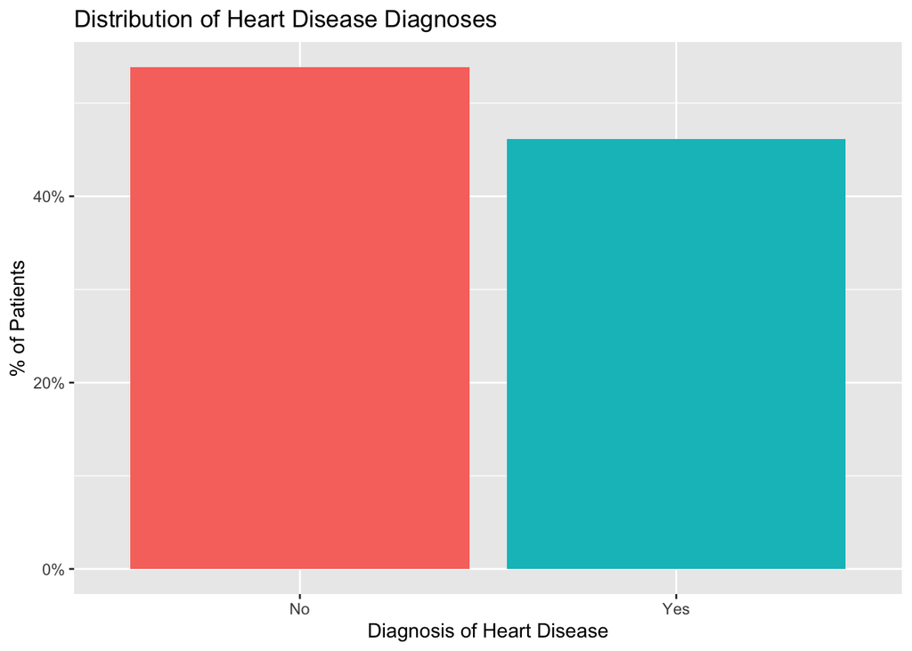

```r
#There are 4 nulls in ca and 2 in thal olumns
#I eliminate them from the dataset

data <- na.omit(data)

#This eliminates 6 rows, which is not a lot
#To simplify the problem I will convert the outcome variable to a categorical variable taking values 1 or 0 and convert to factor

clean_data <- data %>% mutate(num = as.factor(ifelse(num > 0, 1,0)))

######################################################################################################################################################################################################

##Plotting distrbution of outcomes in the dataset

hd_dist <- ggplot(clean_data) +
            geom_bar(aes(x = num, y = (..count..)/sum(..count..), fill = num), position = "dodge") +
            scale_x_discrete(name = "Diagnosis of Heart Disease", labels = c("No", "Yes")) +
            scale_y_continuous(name = "% of Patients", labels = scales::percent) +
            ggtitle("Distribution of Heart Disease Diagnoses") +
            theme(legend.position = "none")

hd_dist
```

```r
######################################################################################################################################################################################################
```

It can be seen that there is almost equal proportions of patients with a heart disease diagnosis (~46%) and those without after reduction to dichotmous form. This is reassuring since it provided enough heterogeneity in the response variable for our analysis.

### 2. Age (age)

This feature indicates the age of the patient in integer form. Below I plot the distribution and its association with diagnosis of heart disease.

**Click here For Code/ Plots**

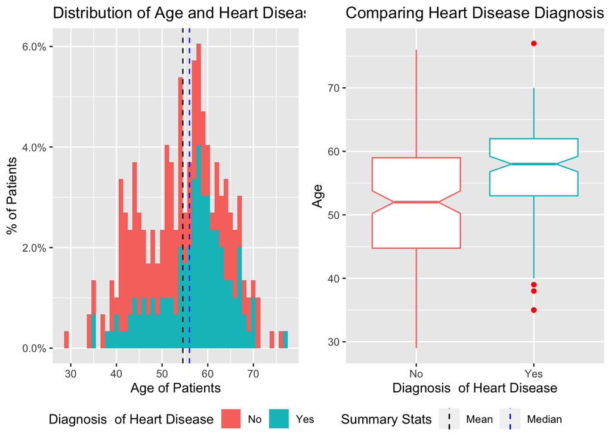

```r
#1. Age

# Histogram of age by Heart Disease prevalence

age_hist<- ggplot(clean_data) +
            geom_histogram(aes(x = age, y = (..count..)/sum(..count..), fill = num), binwidth = 1) +
            scale_y_continuous(name = "% of Patients", labels = scales::percent)+
            scale_x_continuous(name = "Age of Patients", breaks = seq(0,86,10)) +
            scale_fill_discrete(name = "Diagnosis  of Heart Disease", labels = c("No", "Yes")) +
            geom_vline(aes(xintercept = mean(age, na.rm = T),color = "Mean"), linetype = "dashed") +
            geom_vline(aes(xintercept = median(age, na.rm=T),color = "Median"), linetype = "dashed") +
            scale_color_manual(name = "Summary Stats", values = c(Median = "blue", Mean = "black")) +
            ggtitle("Distribution of Age and Heart Diseases Prevalence")





age_bxp <- ggplot(clean_data, aes( x = num, y = age, color = num))  + geom_boxplot(notch = T, outlier.colour = 'red') +
  scale_x_discrete(name = "Diagnosis  of Heart Disease", labels = c("No", "Yes")) +
  scale_y_continuous(name = "Age") +
  theme(legend.position = "none") +
  ggtitle("Comparing Heart Disease Diagnosis  by Age")



age_plots <- ggarrange(age_hist, age_bxp, nrow = 1, ncol =2, common.legend = T, legend = "bottom" )

age_plots
```

It can be observed that there is a fairly symmetric distribution of age with both median and mean values between 50 and 60. The box plot shows that diagnosis of heart disease is assocaited with increased age. Since the notches do not overlap we can say that there is a statistically significant difference between the two distributions.

### 3. Sex (sex)

This is a categorical variable that takes the value 1 for male and 0 for female. Below I look at the distribution of this feature and its association to diagnosis of heart disease.

**Click here For Code/ Plots**

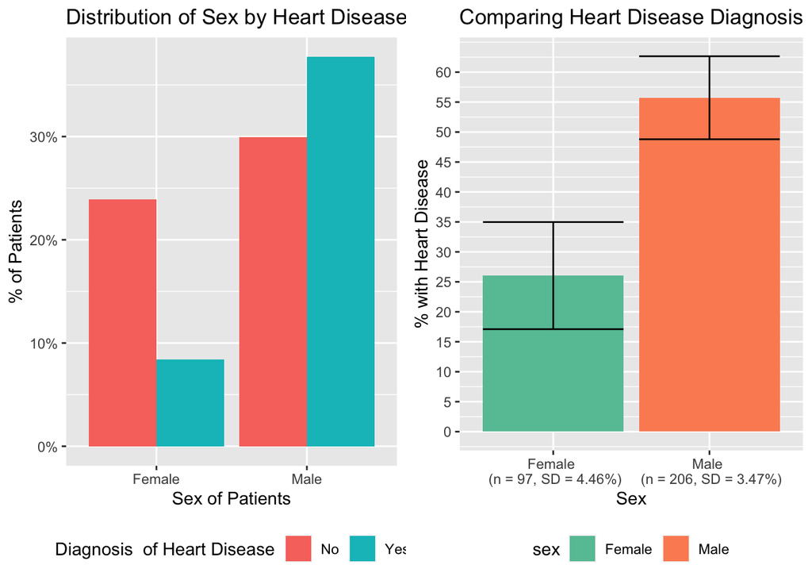

```r
##2. Sex

#Coding as a factor

clean_data <- clean_data %>% mutate(sex = as.factor(sex))

sex_dist <- ggplot(clean_data) +
              geom_bar(aes(x = sex, y = (..count..)/sum(..count..), fill = num), position = "dodge") +
              scale_x_discrete(name = "Sex of Patients", labels = c("Female", "Male")) +
              scale_y_continuous(name = "% of Patients", labels = scales::percent) +
              scale_fill_discrete(name = "Diagnosis  of Heart Disease", labels = c("No", "Yes")) +
              ggtitle("Distribution of Sex by Heart Disease Diagnosis ")

##Checking to see if there is a statistically significant difference in heart disease by sex

hd_sex_test <- group_by(clean_data, sex) %>% summarise(n    = n(),
                                                       mean = ci(as.num.fact(num))[1]*100,
                                                       l_ci = ci(as.num.fact(num))[2]*100,
                                                       h_ci = ci(as.num.fact(num))[3]*100,
                                                       sd   = ci(as.num.fact(num))[4]*100
                                                       )
sex_test_plot <- ggplot(hd_sex_test) +
                  geom_col(aes(x = sex, y = mean, fill = sex ), position = "dodge") +
                  geom_errorbar(aes(x = sex, ymin = l_ci, ymax = h_ci), position = "dodge") +
                  scale_x_discrete(name = "Sex", labels = c("Female \n (n = 97, SD = 4.46%)", "Male \n (n = 206, SD = 3.47%)")) +
                  scale_y_continuous(name = "% with Heart Disease", breaks = seq(0,60,5)) +
                  scale_fill_brewer(type = "qual", palette = 7, aesthetics = "fill", labels = c("Female", "Male")) +
                  theme(legend.position = "none") +
                  ggtitle("Comparing Heart Disease Diagnosis  by Sex (95% CI)")


sex_plots <- ggarrange(sex_dist, sex_test_plot, ncol = 2, legend = "bottom")

sex_plots
```

```r
clean_data <- mutate(clean_data,
                     sex = as.factor(sex))
```

It can be observed that only about a third of the patients are female. We can also see that men are more likely to be diagnosed with heart disease than women; the difference seems to be statitistically significant since the error bars do not overlap.

### 4. Types of Chest Pain (cp)

This is a categorical variable that takes value 1 for Typical Angina, 2 for Atypical Angina, 3 for Non-Anginal Pain, and 4 for Asymptomatic. Below I look at the distribution and association with diagnosis of heart disease.

**Click here For Code/ Plots**

```r
#3. CP - Chest Pain
unique(clean_data$cp)
```

```
## [1] 1 4 3 2
```

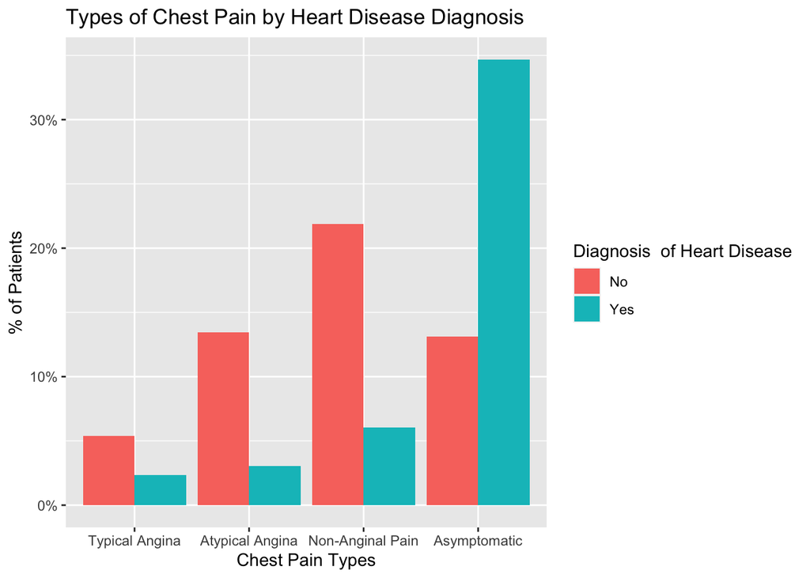

```r
##This variable codes 4 different states with 1,2, and 3 indicating different types of chest pain and 4 codes for no chest pain

##Looking at the frequqncy distribution of the data

cp_dist <- ggplot(clean_data) +
            geom_bar(aes(x = as.factor(cp), y = (..count..)/sum(..count..), fill = num ), position = "dodge")+
              scale_x_discrete(name = "Chest Pain Types", labels = c("Typical Angina", "Atypical Angina", "Non-Anginal Pain", "Asymptomatic")) +
              scale_y_continuous(name = "% of Patients", labels = scales::percent) +
              scale_fill_discrete(name = "Diagnosis  of Heart Disease", labels = c("No", "Yes")) +
              ggtitle("Types of Chest Pain by Heart Disease Diagnosis ")

cp_dist
```

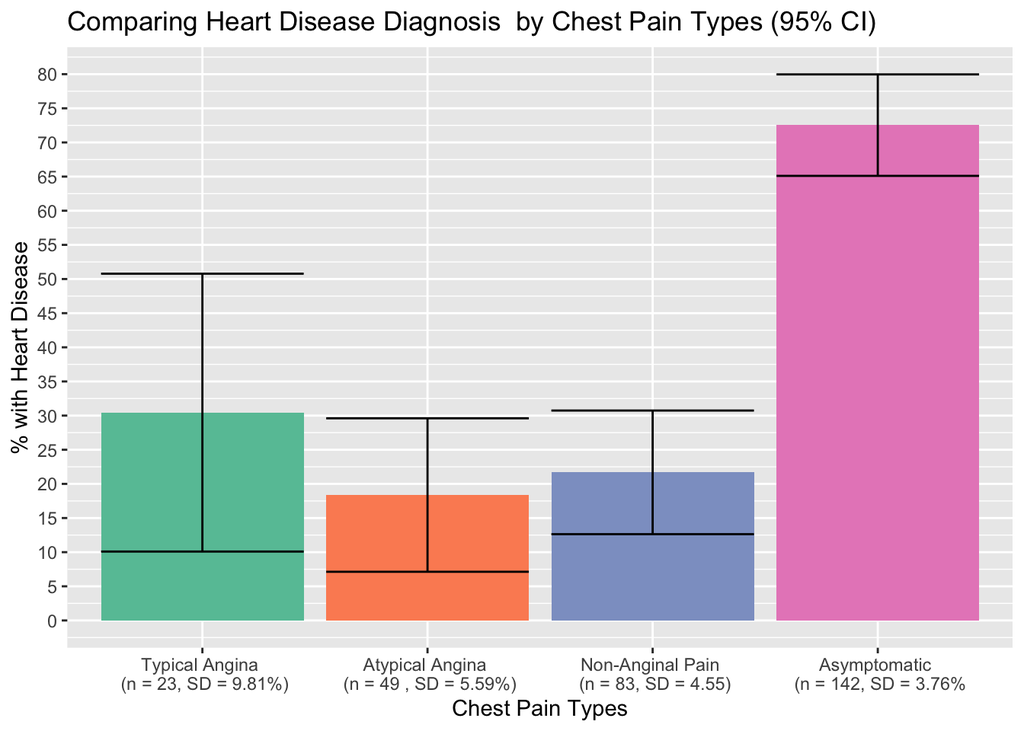

```r
hd_cp_test <- group_by(clean_data, cp ) %>%
                                                   summarise(n    = n(),
                                                   mean = ci(as.num.fact(num))[1]*100,
                                                   l_ci = ci(as.num.fact(num))[2]*100,
                                                   h_ci = ci(as.num.fact(num))[3]*100,
                                                   sd   = ci(as.num.fact(num))[4]*100
                                                   )

cp_test_plot <- ggplot(hd_cp_test) +
                  geom_col(aes(x = as.factor(cp), y = mean, fill = as.factor(cp) ), position = "dodge") +
                  geom_errorbar(aes(x = as.factor(cp), ymin = l_ci, ymax = h_ci), position = "dodge") +
                  scale_x_discrete(name = "Chest Pain Types", labels = c("Typical Angina \n (n = 23, SD = 9.81%)", "Atypical Angina \n (n = 49 , SD = 5.59%)", "Non-Anginal Pain \n (n = 83, SD = 4.55)", "Asymptomatic \n (n = 142, SD = 3.76%")) +
                  scale_y_continuous(name = "% with Heart Disease", breaks = seq(0,80,5)) +
                  scale_fill_brewer(name = "Chest Pain Types", type = "qual", palette = 7, aesthetics = "fill", labels = c("Typical Angina", "Atypical Angina", "Non-Anginal Pain", "Asymptomatic")) +
                  ggtitle("Comparing Heart Disease Diagnosis  by Chest Pain Types (95% CI)") +
                  theme(legend.position = "none")

cp_test_plot
```

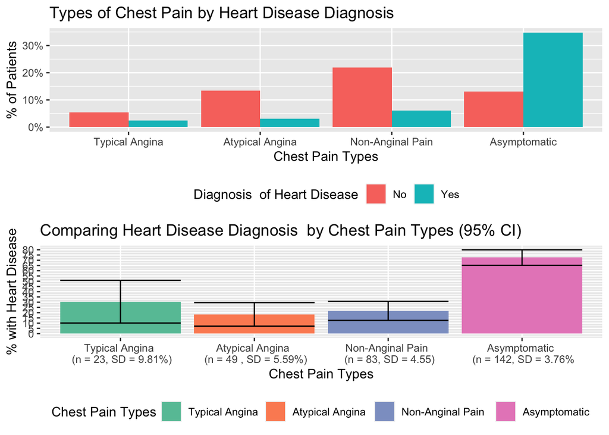

```r
cp_plots <- ggarrange(cp_dist, cp_test_plot, nrow = 2, legend = "bottom")

cp_plots
```

```r
##This is prima-facie a surprising result since it indicates that patients with chest pain of any type seem o have lower occurrence of heart disease
##Nonetheless given the limited variation in heart disease Diagnosis  for those exibhiting pain, I code asymptomatic as 0 and the rest as 1

clean_data <- mutate(clean_data,
                     cp_clean = as.factor(if_else(cp == 4, 0 ,1)))
```

It can be observed that patients reporting Asymptomatic account for almost half of the dataset. However, it also seems that those reported as Asymptomatic have a much higher probability of being diagnosed with heart disease compared to those reporting ny type of chest pain. This is *prima-facie* a counter-intuitive result since Anginal pain is a major symptom of coronary heart disease (from quick googling!). This could be due to an error in the coding of this feature in the data dictionary or due to something specific to how the data was collected. Nonetheless, there is no way to determine why this is the case and I wil choose to trust the data as is.

Since there are 4 different categories, it is worth exploring if this can be reduced to a dichotomous variable. Given the limited variation in the association between different types of pain and diagnosis of heart disease and the three types of pain together account for slightly more than 50% of data, I code this feature as 1 for presence of chest pain and 0 for Asymptomatic/no pain.

### 5. Resting Blood Pressure (trestbps)

This is continuous variable the codes for resting blood pressure at the time of observation. Below I plot the distrbution and association with diagnosis of heart disease.

**Click here For Code/ Plots**

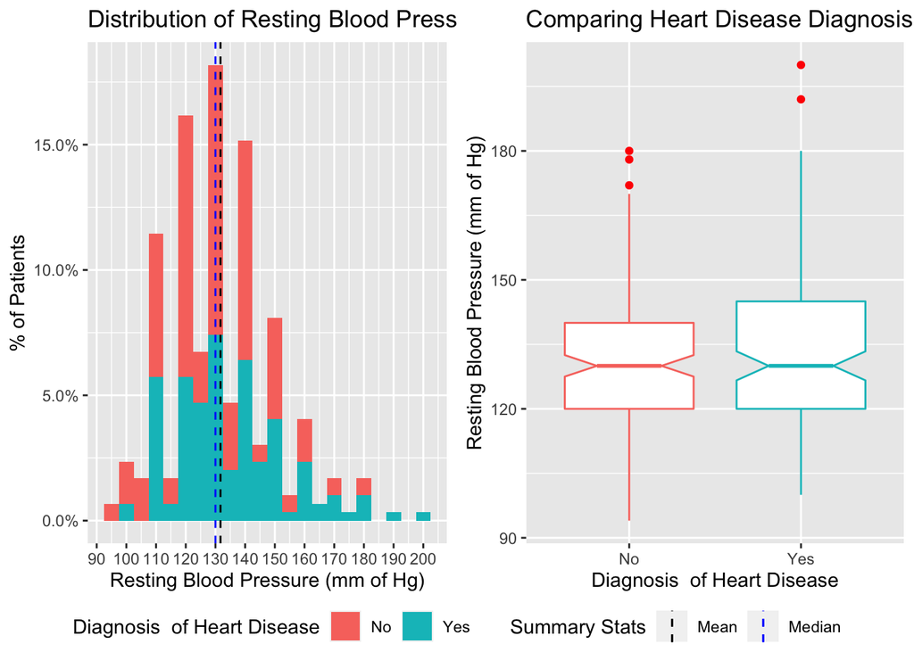

```r
# 4. trestbps

#This is a continuous variable the codes for resting blood pressure on admission to hospital

#distribution of trestbps

trestbps_dist <- ggplot(clean_data) +
                  geom_histogram(aes(x = trestbps, y = (..count..)/sum(..count..), fill = num), binwidth = 5) +
                  scale_y_continuous(name = "% of Patients", labels = scales::percent)+
                  scale_x_continuous(name = "Resting Blood Pressure (mm of Hg)", breaks = seq(90,220,10)) +
                  scale_fill_discrete(name = "Diagnosis  of Heart Disease", labels = c("No", "Yes")) +
                  geom_vline(aes(xintercept = mean(trestbps, na.rm = T),color = "Mean"), linetype = "dashed") +
                  geom_vline(aes(xintercept = median(trestbps, na.rm=T),color = "Median"), linetype = "dashed") +
                  scale_color_manual(name = "Summary Stats", values = c(Median = "blue", Mean = "black")) +
                  ggtitle("Distribution of Resting Blood Pressure and Heart Diseases Prevalence")

trestbps_bxp <- ggplot(clean_data, aes( x = num, y = trestbps, color = num))  + geom_boxplot(notch = T, outlier.colour = 'red') +
                  scale_x_discrete(name = "Diagnosis  of Heart Disease", labels = c("No", "Yes")) +
                  scale_y_continuous(name = "Resting Blood Pressure (mm of Hg)") +
                  theme(legend.position = "none") +
                  ggtitle("Comparing Heart Disease Diagnosis  by Resting Blood Pressure")


trestbps_plots <- ggarrange(trestbps_dist, trestbps_bxp, common.legend = T, legend = "bottom")

trestbps_plots
```

It can be observed that this is more or less symmetrically distributed with mean and median close to 130 mm of Hg. The boxplot indicates that there doesn’t seem to be a statistically significant association between this feature and diagnosis of heart disease.

### 6. Serum Cholestrol Level (chol)

This is a continuous variable that codes for serum cholestrol levels in mg/dl. Below I look at the distribution and its association with diagnosis of heart disease.

**Click here For Code/ Plots**

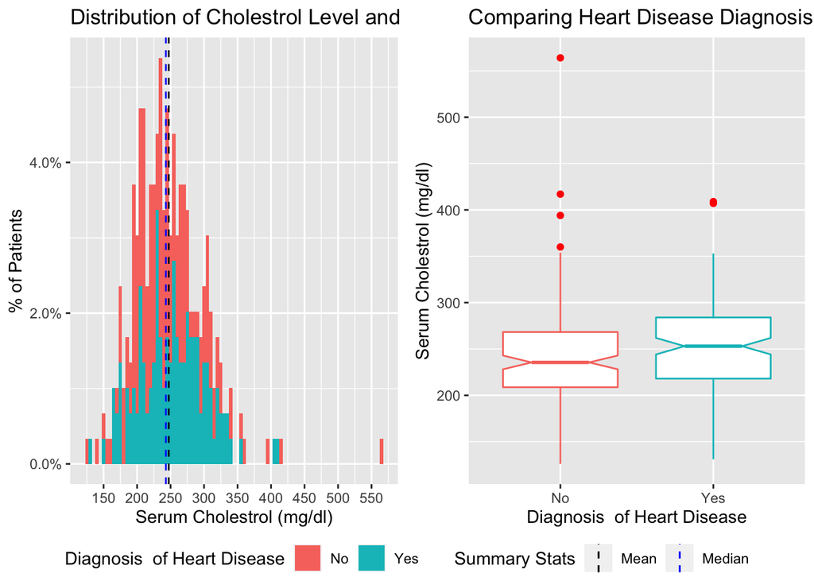

```r
##This is a continuous variable that codes for cholestrol levels in mg/dl

chol_dist <- ggplot(clean_data) +
  geom_histogram(aes(x = chol, y = (..count..)/sum(..count..), fill = num), binwidth = 5) +
  scale_y_continuous(name = "% of Patients", labels = scales::percent)+
  scale_x_continuous(name = "Serum Cholestrol (mg/dl)", breaks = seq(100,600,50) ) +
  scale_fill_discrete(name = "Diagnosis  of Heart Disease", labels = c("No", "Yes")) +
  geom_vline(aes(xintercept = mean(chol, na.rm = T),color = "Mean"), linetype = "dashed") +
  geom_vline(aes(xintercept = median(chol, na.rm=T),color = "Median"), linetype = "dashed") +
  scale_color_manual(name = "Summary Stats", values = c(Median = "blue", Mean = "black")) +
  ggtitle("Distribution of Cholestrol Level and Heart Diseases Prevalence")

chol_bxp <- ggplot(clean_data, aes( x = num, y = chol, color = num))  + geom_boxplot(notch = T, outlier.colour = 'red') +
  scale_x_discrete(name = "Diagnosis  of Heart Disease", labels = c("No", "Yes")) +
  scale_y_continuous(name = "Serum Cholestrol (mg/dl)") +
  theme(legend.position = "none") +
  ggtitle("Comparing Heart Disease Diagnosis  by Cholestrol Level")


chol_plots <- ggarrange(chol_dist, chol_bxp, common.legend = T, legend = "bottom")

chol_plots
```

It can be seen that the distribution is almost symmetric with a few outliers on the right. The boxplot indicates that there is not a statistically signifcant association between this feature and diagnosis of heart disease.

### 7. Fasting Blood Sugar Level (fbs)

This is a categorical variable that takes value 1 when fasting blood sugar level is above > 120 mg/dl. Below I look at the distribution and assocaition with diagnosis of heart disease.

**Click here For Code/ Plots**

[figure not shown]

```r
#6. fbs

#This is a categorical variable that takes value 1 when fasting blood sugar level is above > 120 mg/dl

#Coding as a factor

clean_data <- clean_data %>% mutate(fbs = as.factor(fbs))

#Plotting the Distribution
fbs_dist <- ggplot(clean_data) +
  geom_bar(aes(x = fbs, y = (..count..)/sum(..count..), fill = num), position = "dodge") +
  scale_x_discrete(name = "Fasting Blood Sugar", labels = c("< 120mg/dl", "> 120mg/dl")) +
  scale_y_continuous(name = "% of Patients", labels = scales::percent) +
  scale_fill_discrete(name = "Diagnosis  of Heart Disease", labels = c("No", "Yes")) +
  ggtitle("Distribution of Fasting Blood Sugar by Heart Disease Diagnosis ")

##Checking to see if there is a statistically significant difference in heart disease by fasting blood sugar

hd_fbs_test <- group_by(clean_data, fbs) %>% summarise(n    = n(),
                                                       mean = ci(as.num.fact(num))[1]*100,
                                                       l_ci = ci(as.num.fact(num))[2]*100,
                                                       h_ci = ci(as.num.fact(num))[3]*100,
                                                       sd   = ci(as.num.fact(num))[4]*100
)


fbs_test_plot <- ggplot(hd_fbs_test) +
  geom_col(aes(x = fbs, y = mean, fill = fbs ), position = "dodge") +
  geom_errorbar(aes(x = fbs, ymin = l_ci, ymax = h_ci), position = "dodge") +
  scale_x_discrete(name = "Fasting Blood Sugar", labels = c("< 120mg/dl \n (n = 254, SD = 3.13%)", "> 120mg/dl \n (n = 254, SD = 7.7%)")) +
  scale_y_continuous(name = "% with Heart Disease", breaks = seq(0,60,5)) +
  scale_fill_brewer(name = "Fasting Blood Sugar",type = "qual", palette = 7, aesthetics = "fill", labels = c("< 120mg/dl", "> 120mg/dl")) +
  theme(legend.position = "none") +
  ggtitle("Comparing Heart Disease Diagnosis  by Fasting Blood Sugar (95% CI)")



fbs_plots <- ggarrange(fbs_dist, fbs_test_plot, ncol = 2, legend = "bottom")

fbs_plots
```

```r
clean_data <- mutate(clean_data,
                     fbs = as.factor(fbs))
```

The frequency plot shows that most patients (> 80%) have fasting blood sugar below 120 mg/dl. We can also see from both plots that this doesn’t seem to have significant association with diagnosis of heart disease.

### 8. Resting ECG (restecg)

This is a categorical variable that is coded using the resting electro cardiogram results taking 3 values; 0 for normal, 1 for Having ST-T Abnormality, 2 for showing probable or definite left ventricular hypertrophy by Estes’ criteria. Below I look at the distribution and assocaition with diagnosis of heart disease.

**Click here For Code/ Plots**

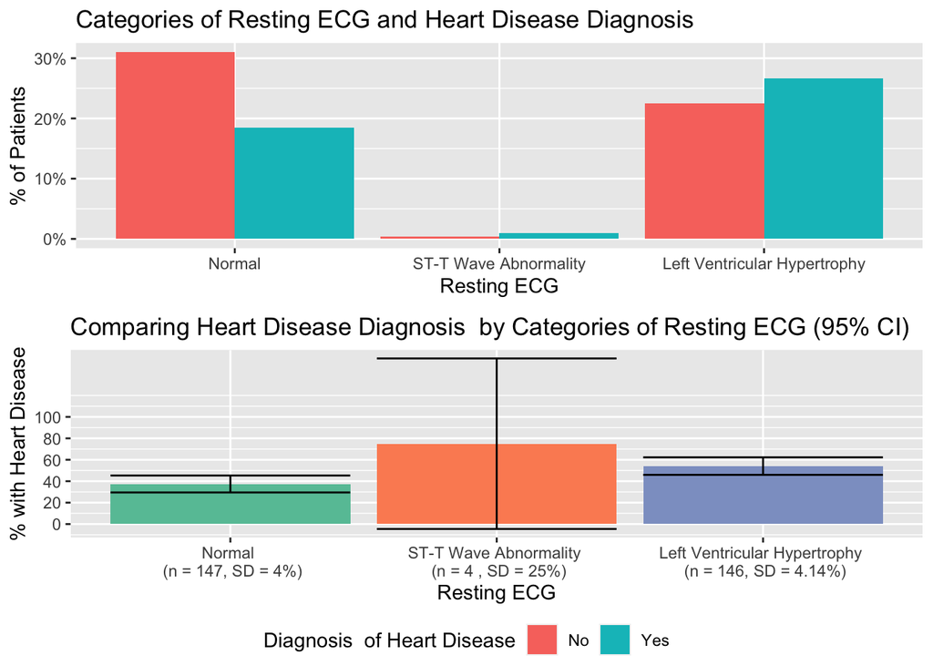

```r
#7. restecg

##This is a categorical variable that is coded using the resting electro cardiogram results taking 3 values;
#0 for normal, 1 for Having ST-T Abnormality, 2 for showing probable or definite left ventricular hypertrophy by Estes' criteria

## Given I do not know what these terms mean, I look at the prevalence of each category and its association to heart disease

restecg_dist <- ggplot(clean_data) +
  geom_bar(aes(x = as.factor(restecg), y = (..count..)/sum(..count..), fill = num ), position = "dodge")+
  scale_x_discrete(name = "Resting ECG", labels = c("Normal", "ST-T Wave Abnormality", "Left Ventricular Hypertrophy")) +
  scale_y_continuous(name = "% of Patients", labels = scales::percent) +
  scale_fill_discrete(name = "Diagnosis  of Heart Disease", labels = c("No", "Yes")) +
  ggtitle("Categories of Resting ECG and Heart Disease Diagnosis ")



hd_restecg_test <- group_by(clean_data, restecg ) %>%
  summarise(n    = n(),
            mean = ci(as.num.fact(num))[1]*100,
            l_ci = ci(as.num.fact(num))[2]*100,
            h_ci = ci(as.num.fact(num))[3]*100,
            sd   = ci(as.num.fact(num))[4]*100
  )

restecg_test_plot <- ggplot(hd_restecg_test) +
  geom_col(aes(x = as.factor(restecg), y = mean, fill = as.factor(restecg) ), position = "dodge") +
  geom_errorbar(aes(x = as.factor(restecg), ymin = l_ci, ymax = h_ci), position = "dodge") +
  scale_x_discrete(name = "Resting ECG", labels = c("Normal \n (n = 147, SD = 4%)", "ST-T Wave Abnormality \n (n = 4 , SD = 25%)", "Left Ventricular Hypertrophy \n (n = 146, SD = 4.14%)")) +
  scale_y_continuous(name = "% with Heart Disease", breaks = seq(0,100,20)) +
  scale_fill_brewer(name = "Chest Pain Types", type = "qual", palette = 7, aesthetics = "fill", labels = c("Normal", "ST-T Wave Abnormality", "Left Ventricular Hypertrophy")) +
  ggtitle("Comparing Heart Disease Diagnosis  by Categories of Resting ECG (95% CI)") +
  theme(legend.position = "none")



restecg_plots <- ggarrange(restecg_dist, restecg_test_plot, nrow = 2, legend = "bottom", common.legend = T)

restecg_plots
```

```r
##Given that there are very few instance of ST-T Wave Abnormality in the data and it doesn't seem to provide a strong signal regarding probability of heart disease, I code this variable as 0 for normal and 1 for abnormal

clean_data <- mutate(clean_data,
                     restecg_clean = as.factor(if_else(restecg >0,1,0)))
```

It can be seen that save for ST-T Wave Abnormality, both other result types appear almost equal number of times in the data. Normal result seems to be slighlty less associated with diagnosis of heart disease compared to the other two types. Given that there are very few instance of ST-T Wave Abnormality in the data and it doesn’t seem to provide a strong signal regarding probability of heart disease, I code this variable as 0 for normal and 1 for abnormal.

### 9. Maximum Heart Rate Achieved During Thalium Test (thalach)

**Click here For Code/ Plots**

This is a continuous variables that codes for maximum heart rate achieved during a Thalium test. Below I look at the distribution and association with diagnosis of heart disease.

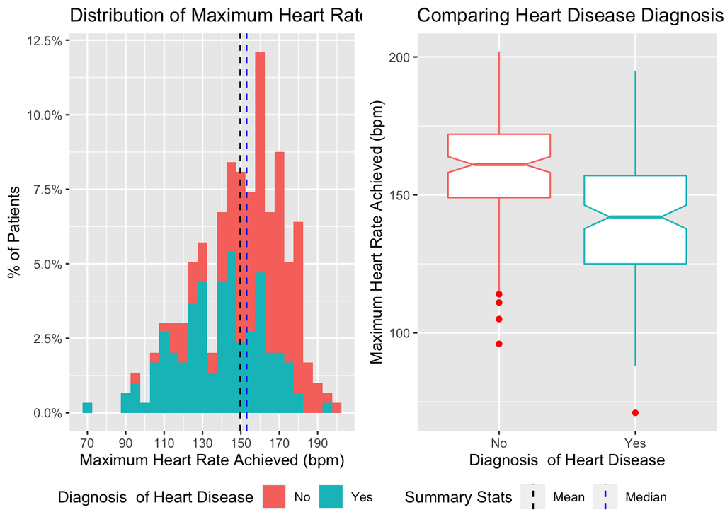

```r
######################################################################################################################################################################################################
#8. Thalach

##This is a continuous variables that codes for maximum heart rate achieved;

thalach_dist <- ggplot(clean_data) +
  geom_histogram(aes(x = thalach, y = (..count..)/sum(..count..), fill = num), binwidth = 5) +
  scale_y_continuous(name = "% of Patients", labels = scales::percent)+
  scale_x_continuous(name = "Maximum Heart Rate Achieved (bpm)", breaks = seq(70,210,20) ) +
  scale_fill_discrete(name = "Diagnosis  of Heart Disease", labels = c("No", "Yes")) +
  geom_vline(aes(xintercept = mean(thalach, na.rm = T),color = "Mean"), linetype = "dashed") +
  geom_vline(aes(xintercept = median(thalach, na.rm=T),color = "Median"), linetype = "dashed") +
  scale_color_manual(name = "Summary Stats", values = c(Median = "blue", Mean = "black")) +
  ggtitle("Distribution of Maximum Heart Rate Achieved and Heart Diseases Prevalence")

thalach_bxp <- ggplot(clean_data, aes( x = num, y = thalach, color = num))  + geom_boxplot(notch = T, outlier.colour = 'red') +
  scale_x_discrete(name = "Diagnosis  of Heart Disease", labels = c("No", "Yes")) +
  scale_y_continuous(name = "Maximum Heart Rate Achieved (bpm)") +
  theme(legend.position = "none") +
  ggtitle("Comparing Heart Disease Diagnosis  by Maximum Heart Rate Achieved Level")


thalach_plots <- ggarrange(thalach_dist, thalach_bxp, common.legend = T, legend = "bottom")

thalach_plots
```

### 10. Exercise Induced Angina (exang)

**Click here For Code/ Plots**

This is a categorical variable that codes for exercise induced angina – 1 for Yes and 0 for No. Below I look at the distribution and association with diagnosis of heart disease.

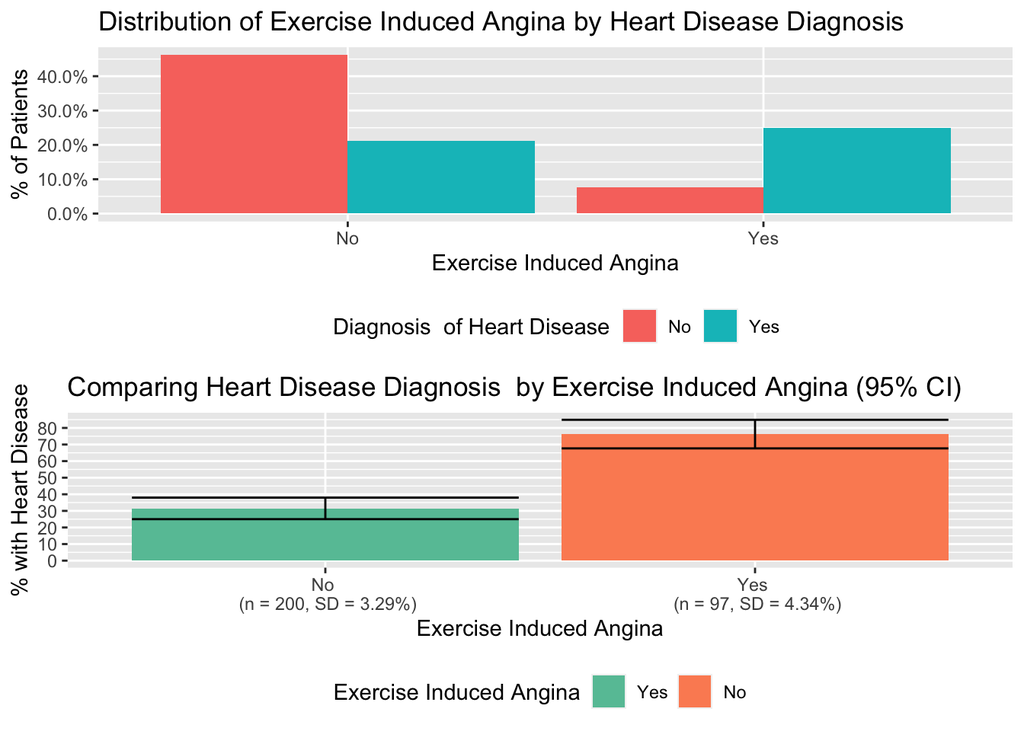

```r
# 9. exang

## This is a categorical variable that codes for exercise induced angina -- 1 for Yes and 0 for No

##Converting to factor

clean_data <- clean_data %>% mutate(exang = as.factor(exang))

exang_dist <- ggplot(clean_data) +
  geom_bar(aes(x = exang, y = (..count..)/sum(..count..), fill = num), position = "dodge") +
  scale_x_discrete(name = "Exercise Induced Angina", labels = c("No", "Yes")) +
  scale_y_continuous(name = "% of Patients", labels = scales::percent) +
  scale_fill_discrete(name = "Diagnosis  of Heart Disease", labels = c("No", "Yes")) +
  ggtitle("Distribution of Exercise Induced Angina by Heart Disease Diagnosis ")

##Checking to see if there is a statistically significant difference in heart disease by exang

hd_exang_test <- group_by(clean_data, exang) %>% summarise(n    = n(),
                                                       mean = ci(as.num.fact(num))[1]*100,
                                                       l_ci = ci(as.num.fact(num))[2]*100,
                                                       h_ci = ci(as.num.fact(num))[3]*100,
                                                       sd   = ci(as.num.fact(num))[4]*100
)
exang_test_plot <- ggplot(hd_exang_test) +
  geom_col(aes(x = exang, y = mean, fill = exang ), position = "dodge") +
  geom_errorbar(aes(x = exang, ymin = l_ci, ymax = h_ci), position = "dodge") +
  scale_x_discrete(name = "Exercise Induced Angina", labels = c("No \n (n = 200, SD = 3.29%)", "Yes \n (n = 97, SD = 4.34%)")) +
  scale_y_continuous(name = "% with Heart Disease", breaks = seq(0,100,10)) +
  scale_fill_brewer(name = "Exercise Induced Angina", type = "qual", palette = 7, aesthetics = "fill", labels = c("Yes", "No")) +
  theme(legend.position = "none") +
  ggtitle("Comparing Heart Disease Diagnosis  by Exercise Induced Angina (95% CI)")


exang_plots <- ggarrange(exang_dist, exang_test_plot, ncol = 1, legend = "bottom")

exang_plots
```

```r
##There is a clear association between experiencing exercise induced angina and Diagnosis  of heart disease

clean_data <- mutate(clean_data,
                     exang = as.factor(exang))
```

### 11. ST Depression Induced by Exercise Relative to Rest (oldpeak)

This is a continuous variable that codes for ST depression induced by exercise relative to rest. It’s unclear what this means to me, so I perform some basic tests of association.

**Click here For Code/ Plots**

```r
#11 oldpeak

# This is a continuous variable that codes for ST depression induced by exercise relative to rest. It's unclear what this means to me, so I perform some basic tests of assocaition and prevalence

summary(clean_data$oldpeak)
```

```
##    Min. 1st Qu.  Median    Mean 3rd Qu.    Max.
##   0.000   0.000   0.800   1.056   1.600   6.200
```

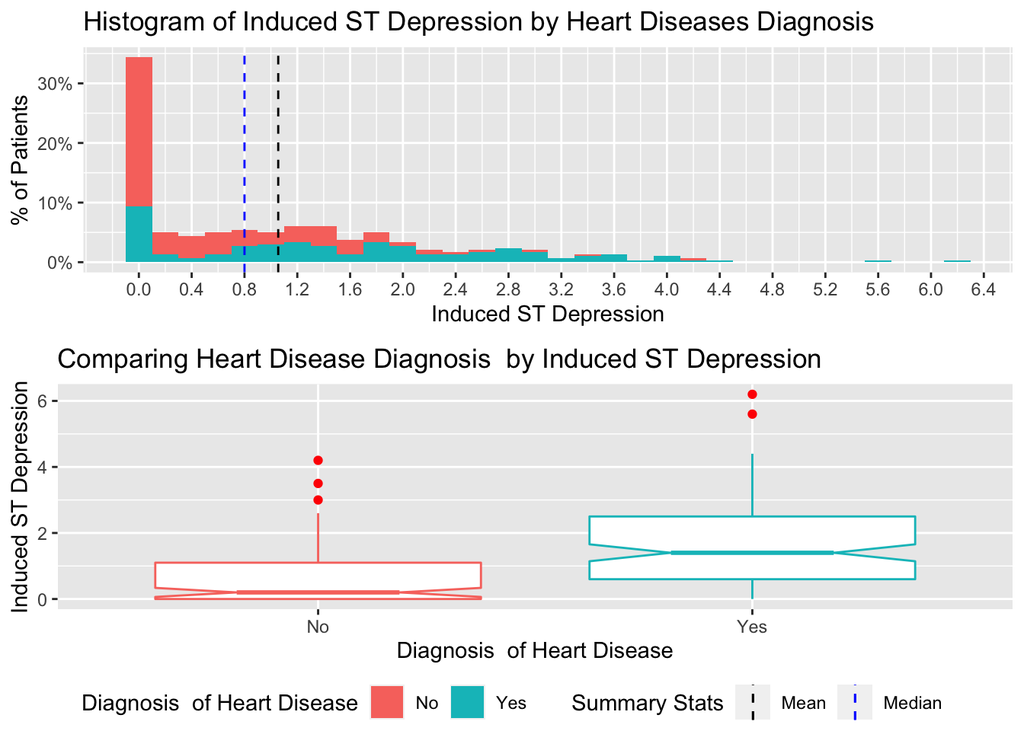

```r
oldpeak_dist <- ggplot(clean_data) +
  geom_histogram(aes(x = oldpeak, y = (..count..)/sum(..count..), fill = num), binwidth = 0.2) +
  scale_y_continuous(name = "% of Patients", labels = scales::percent)+
  scale_x_continuous(name = "Induced ST Depression", breaks = seq(0,6.4,0.4) ) +
  scale_fill_discrete(name = "Diagnosis  of Heart Disease", labels = c("No", "Yes")) +
  geom_vline(aes(xintercept = mean(oldpeak, na.rm = T),color = "Mean"), linetype = "dashed") +
  geom_vline(aes(xintercept = median(oldpeak, na.rm=T),color = "Median"), linetype = "dashed") +
  scale_color_manual(name = "Summary Stats", values = c(Median = "blue", Mean = "black")) +
  ggtitle("Histogram of Induced ST Depression by Heart Diseases Diagnosis ")



oldpeak_bxp <- ggplot(clean_data, aes( x = num, y = oldpeak, color = num))  + geom_boxplot(notch = T, outlier.colour = 'red') +
  scale_x_discrete(name = "Diagnosis  of Heart Disease", labels = c("No", "Yes")) +
  scale_y_continuous(name = "Induced ST Depression") +
  theme(legend.position = "none") +
  ggtitle("Comparing Heart Disease Diagnosis  by Induced ST Depression")


oldpeak_plots <- ggarrange(oldpeak_dist, oldpeak_bxp, common.legend = T, legend = "bottom", ncol = 1)


oldpeak_plots
```

```r
##There seems to be a statistically significant association between higher ST depression and Diagnosis  of heart disease
```

### 12. Slope of ST Segment During Peak Exercise (slope)

This is a categorical variable that codes the slope of the ST segment during peak exercise; 1 for upward sloping, 2 for flat, and 3 for downward sloping. It’s unclear what this means to me, so I perform some basic tests of association.

**Click here For Code/ Plots**

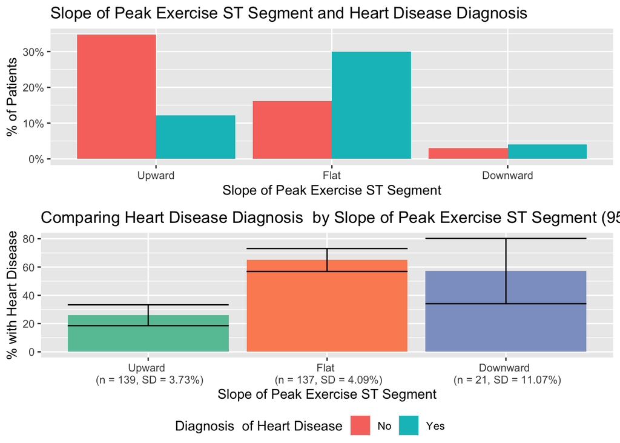

```r
# 12 slope

##This is a categorical variable that codes the slope of the ST segment during peak exercise; 1 for upward sloping, 2 for flat, and 3 for downward sloping


## Given I do not know what these terms mean, I look at the prevalence of each category and its association to heart disease

slope_dist <- ggplot(clean_data) +
  geom_bar(aes(x = as.factor(slope), y = (..count..)/sum(..count..), fill = num ), position = "dodge")+
  scale_x_discrete(name = "Slope of Peak Exercise ST Segment", labels = c("Upward", "Flat", "Downward")) +
  scale_y_continuous(name = "% of Patients", labels = scales::percent) +
  scale_fill_discrete(name = "Diagnosis  of Heart Disease", labels = c("No", "Yes")) +
  ggtitle("Slope of Peak Exercise ST Segment and Heart Disease Diagnosis ")



hd_slope_test <- group_by(clean_data, slope ) %>%
  summarise(n    = n(),
            mean = ci(as.num.fact(num))[1]*100,
            l_ci = ci(as.num.fact(num))[2]*100,
            h_ci = ci(as.num.fact(num))[3]*100,
            sd   = ci(as.num.fact(num))[4]*100
  )

slope_test_plot <- ggplot(hd_slope_test) +
  geom_col(aes(x = as.factor(slope), y = mean, fill = as.factor(slope) ), position = "dodge") +
  geom_errorbar(aes(x = as.factor(slope), ymin = l_ci, ymax = h_ci), position = "dodge") +
  scale_x_discrete(name = "Slope of Peak Exercise ST Segment", labels = c("Upward \n (n = 139, SD = 3.73%)", "Flat \n (n = 137, SD = 4.09%)", "Downward \n (n = 21, SD = 11.07%)")) +
  scale_y_continuous(name = "% with Heart Disease", breaks = seq(0,100,20)) +
  scale_fill_brewer(name = "Chest Pain Types", type = "qual", palette = 7, aesthetics = "fill", labels = c("Normal", "ST-T Wave Abnormality", "Left Ventricular Hypertrophy")) +
  ggtitle("Comparing Heart Disease Diagnosis  by Slope of Peak Exercise ST Segment (95% CI)") +
  theme(legend.position = "none")



slope_plots <- ggarrange(slope_dist, slope_test_plot, nrow = 2, legend = "bottom", common.legend = T)

slope_plots
```

```r
##Since Downward and Flat Slope seems to have similar association to heart disease Diagnosis  I code them as 1 and upward as zero; There are also way fewer samples of downward sloping so it does not make sense to dummify these variable

#Coding as a dichotmous variable

clean_data <- mutate(clean_data,
                     slope_clean = as.factor(if_else(slope >1 ,1,0)))
```

Just 7% of patients demonstrate downward slope with both other categories showing almost equal frequencies. There seems to be a greater probability of heart disease diagnosis with either a flat or downward slope. Since Downward and Flat Slope seems to have similar association to heart disease Diagnosis I code them as 1 and upward as zero; There are also way fewer samples of downward sloping so it does not make sense to dummify this feature.

### 13. Number of Coloured Vessels by Fluoroscopy (ca)

This is a integer variable that codes for the number of vessels colored by fluoroscopy with the integer indication the number of vessels. Below I look at the distribution and association with diagnosis of heart disease.

**Click here For Code/ Plots**

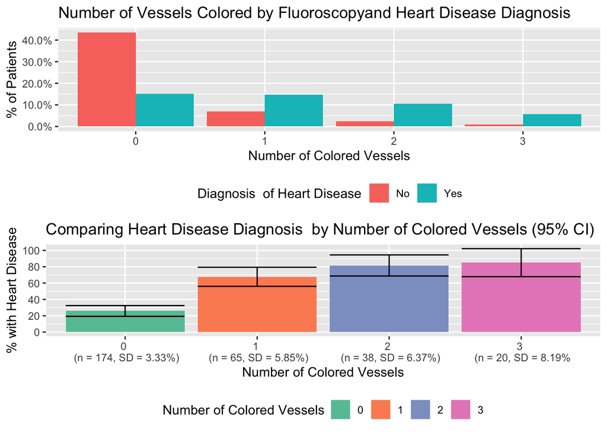

```r
# 13. ca

## This is a integer variable that codes for the number of vessels colored by fluoroscopy with the integer indicating the number of vessels.

##I will look at the distribution and association with heart disease to understand how we should treat this variable

ca_dist <- ggplot(clean_data) +
  geom_bar(aes(x = as.factor(ca), y = (..count..)/sum(..count..), fill = num ), position = "dodge")+
  scale_x_discrete(name = "Number of Colored Vessels") +
  scale_y_continuous(name = "% of Patients", labels = scales::percent) +
  scale_fill_discrete(name = "Diagnosis  of Heart Disease", labels = c("No", "Yes")) +
  ggtitle("Number of Vessels Colored by Fluoroscopyand Heart Disease Diagnosis ")



hd_ca_test <- group_by(clean_data, ca ) %>%
  summarise(n    = n(),
            mean = ci(as.num.fact(num))[1]*100,
            l_ci = ci(as.num.fact(num))[2]*100,
            h_ci = ci(as.num.fact(num))[3]*100,
            sd   = ci(as.num.fact(num))[4]*100
  )

ca_test_plot <- ggplot(hd_ca_test) +
  geom_col(aes(x = as.factor(ca), y = mean, fill = as.factor(ca) ), position = "dodge") +
  geom_errorbar(aes(x = as.factor(ca), ymin = l_ci, ymax = h_ci), position = "dodge") +
  scale_x_discrete(name = "Number of Colored Vessels", labels = c("0 \n (n = 174, SD = 3.33%)", "1 \n (n = 65, SD = 5.85%)", "2 \n (n = 38, SD = 6.37%)", "3 \n (n = 20, SD = 8.19%")) +
  scale_y_continuous(name = "% with Heart Disease", breaks = seq(0,100,20)) +
  scale_fill_brewer(name = "Number of Colored Vessels", type = "qual", palette = 7, aesthetics = "fill") +
  ggtitle("Comparing Heart Disease Diagnosis  by Number of Colored Vessels (95% CI)") +
  theme(legend.position = "none")


ca_plots <- ggarrange(ca_dist, ca_test_plot, ncol = 1, legend = "bottom")

ca_plots
```

```r
##Since the association between having one or more coloured vessel and heart disease is similar, I code this variable as 1 for Diagnosis  of colored vessels and 0 for none. Given the limited samples for 2 and 3 coloured vessels it doesn't make much sense to dummify this variable

#Coding as factor

clean_data <- mutate(clean_data,
                     ca_clean = as.factor(if_else(ca > 0,1,0)))
```

Slightly more than half the patients seem to show no colored vessels as a result of this test.There seems to be significant association between showing no colored vessel and lower probability of heart disease diagnosis. Since the association between having one or more coloured vessel and heart disease is similar, I code this variable as 1 for presence of colored vessels and 0 for none. Given the limited samples for 2 and 3 colored vessels it doesn’t make much sense to dummify this variable.

### 14. Thalium Stress Test Result (Thal)

This is categorical variable that codes the result of the Thalium stress test; 3 for normal, 6 for fixed defect and 7 for reversible defect. Given I do not know what these terms mean, so I look at the prevalence of each category and its association to heart disease diagnosis.

**Click here For Code/ Plots**

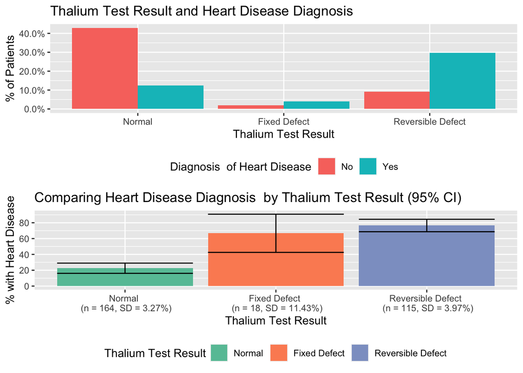

```r
# 14. thal

##This is categorical variable that codes the result of the Thalium stress test; 3 for normal, 6 for fixed defect and 7 for reversible defect

## Given I do not know what these terms mean, I look at the prevalence of each category and its association to heart disease

thal_dist <- ggplot(clean_data) +
  geom_bar(aes(x = as.factor(thal), y = (..count..)/sum(..count..), fill = num ), position = "dodge")+
  scale_x_discrete(name = "Thalium Test Result", labels = c("Normal", "Fixed Defect", "Reversible Defect")) +
  scale_y_continuous(name = "% of Patients", labels = scales::percent) +
  scale_fill_discrete(name = "Diagnosis  of Heart Disease", labels = c("No", "Yes")) +
  ggtitle("Thalium Test Result and Heart Disease Diagnosis ")


hd_thal_test <- group_by(clean_data, thal ) %>%
  summarise(n    = n(),
            mean = ci(as.num.fact(num))[1]*100,
            l_ci = ci(as.num.fact(num))[2]*100,
            h_ci = ci(as.num.fact(num))[3]*100,
            sd   = ci(as.num.fact(num))[4]*100
  )

thal_test_plot <- ggplot(hd_thal_test) +
  geom_col(aes(x = as.factor(thal), y = mean, fill = as.factor(thal) ), position = "dodge") +
  geom_errorbar(aes(x = as.factor(thal), ymin = l_ci, ymax = h_ci), position = "dodge") +
  scale_x_discrete(name = "Thalium Test Result", labels = c("Normal \n (n = 164, SD = 3.27%)", "Fixed Defect \n (n = 18, SD = 11.43%)", "Reversible Defect \n (n = 115, SD = 3.97%)")) +
  scale_y_continuous(name = "% with Heart Disease", breaks = seq(0,100,20)) +
  scale_fill_brewer(name = "Thalium Test Result", type = "qual", palette = 7, aesthetics = "fill", labels = c("Normal", "Fixed Defect", "Reversible Defect")) +
  ggtitle("Comparing Heart Disease Diagnosis  by Thalium Test Result (95% CI)") +
  theme(legend.position = "none")



thal_plots <- ggarrange(thal_dist, thal_test_plot, nrow = 2, legend = "bottom")

thal_plots
```

```r
##Since we can clearly observe a positive association between have either kind of defect and probability of heart disease, I code this variable as dichotomous with 1 for presence of defect and 0 for normal

#converting to a factor

clean_data <- mutate(clean_data,
                     thal_clean = as.factor(if_else(thal > 3, 1,0)))
```

It can be seen that slight over half of the patients return a normal result(~55%). There is also a clear association between a normal test result and decreased probability of heart disease diagnosis. Therefore I code this variable as dichotomous with 1 for presence of defect and 0 for normal.

### Comparing The Naive Association of Features with Heart Disease Diagnosis

As conclusion to Part 1, I shall provide a framework to compare the features on their association with heart disease diagnosis. This frameworks uses two different but related metrics for categorical and continuous features.

#### Continuous Variables

For continuous variables, first I calculate the difference in arithmetic means for that variable between the cohort of patients diagnosed with heart disease versus the cohort that has not been diagnosed with heart disease. I express this as a percentage of the pooled standard deviation of that variable. I also check to ensure this difference is statistically significant using a two sided t-Test. This is a useful way to compare the importance of these features relative to each other. Larger the absolute value greater is the associational importance of that variable.

I call this metric Importance and use $\Delta_{CONT}$ to denote it. Mathematically defined below:

${\Delta_{CONT}(Var) = \dfrac{({\mu_{Var | H = 1}^{\hat{}} - \mu_{Var| H = 0}^{\hat{}}})}{\sqrt{\sigma_{Var}^{2}}} \times 100}$

Below I plot all the continuous features on their absolute value of $\Delta_{CONT}$.

**Click here For Code/Plots**

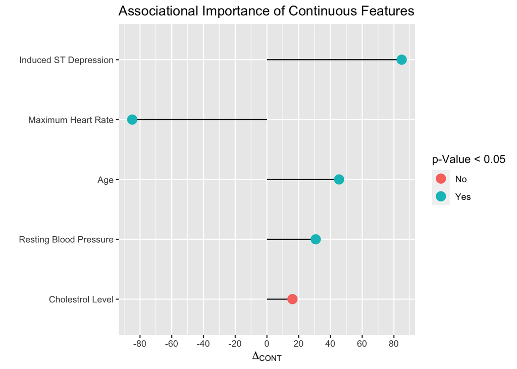

```r
##Conclusion to Part 2

#After cleaning and testing for naive associations, I find that 10 out of the 13 show some form of statistically significant association with heart disease based on t test for difference in means

#Removing variables that have been cleaned.
final_data <- dplyr::select(clean_data,
                     -c(cp, restecg, slope,ca,thal))

##Summarizing difference in means as a percentage of standard deviation in the value for continuous variables

cont_naive_means <- data.frame(variable = names(dplyr::select(final_data, where( is.numeric))), mean_diff = rep(NA, 5), p_value = rep(NA, 5)  )

#Looping through variables to populate the dataframe using UDFs I wrote

for(i in cont_naive_means$variable){

  cont_naive_means$mean_diff[cont_naive_means$variable == i] <- round(cont_mean_pct_sd(i),2)
  cont_naive_means$p_value[cont_naive_means$variable == i] <- cont_p_value(i)

}

##Same for categorical variables

cat_naive_means <- data.frame(variable = names(dplyr::select_if(final_data, is.factor)), mean_diff = rep(NA, 9), p_value = rep(NA, 9)  )

##Removing the row with num

cat_naive_means <- cat_naive_means[cat_naive_means$variable!= "num",]

##Looping through using UDFsI wrote

for(i in cat_naive_means$variable){

  cat_naive_means$mean_diff[cat_naive_means$variable == i] <- round(cat_mean_pct_sd(i),2)
  cat_naive_means$p_value[cat_naive_means$variable == i] <- cat_p_value(i)

}

##Plotting

#Continuous Variables
cont_naive_means <- mutate(cont_naive_means,
                           variable = as.factor(variable),
                           sig = if_else(p_value<0.05,1,0))

cont_naive_means$variable <- fct_reorder( cont_naive_means$variable, (abs(cont_naive_means$mean_diff)))

ggplot(cont_naive_means) +
  geom_segment(aes( x= 0, xend = mean_diff, y = variable , yend = variable )) +
  geom_point(aes(x = mean_diff, y = variable, color = as.factor(sig)), size = 4)+
  scale_color_discrete(name = "p-Value < 0.05", labels = c("No", "Yes")) +
  scale_x_continuous(name = bquote(Delta["CONT"]), breaks = seq(-100,100,20)) +
  scale_y_discrete(name = "", labels = c ("Cholestrol Level","Resting Blood Pressure", "Age", "Maximum Heart Rate", "Induced ST Depression")) +
  ggtitle("Associational Importance of Continuous Features")
```

From this plot we can see that both Induced ST Depression and Maixmum Heart Rate have largest absolute value of $\Delta_{CONT}$. Assuming that they are both results from the same test, it makes sense that they have similar importance. Another interesting fact is that Resting Blood Pressure seems to show a statistically significant difference in means, even though I noted earlier that the association seems to be weak. A second look at the boxplot suggests that this maybe because of a few outlier that is skewing the mean; the medians do not seem to show a statistically significant difference.

#### Categorical Variables

For categorical variables, I first compute the proportion of patients with a heart diagnosis in each category. Since I re-coded all categorical variables as dichotomous, I compute the difference in proportions when the variable is 1 and when it is 0. In most cases 0 indicated Normal; so we can think of the difference as an effect. I perform a t-Test to check for statistical significance and express the difference as a percentage of the overall standard deviation in the proportion of patients diagnosed with heart disease. Similar to the metric for continuous variables, this gives us a useful way to study the relative importance of categorical variables on the basis of their association with heart disease diagnosis.

I call this metric Importance and use $\Delta_{CAT}$ to denote it. Mathematically defined below:

${\Delta_{CAT}(Var) = \dfrac{({\mu_{H | Var = 1}^{\hat{}} - \mu_{H| Var = 0}^{\hat{}}})}{\sqrt{\sigma_{H}^{2}}} \times 100}$

Below I plot all the continuous features on their absolute value of $\Delta_{CAT}$.

**Click here For Code/Plots**

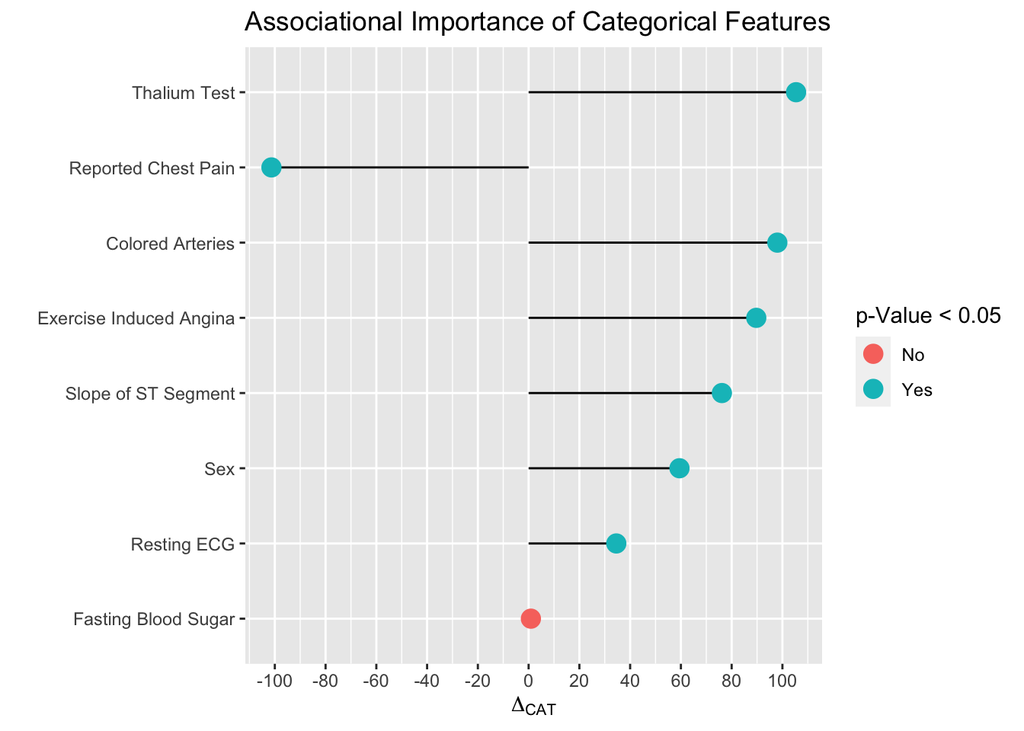

```r
##Categorical Variables

cat_naive_means <- mutate(cat_naive_means,
                           variable = as.factor(variable),
                           sig = if_else(p_value<0.05,1,0))

cat_naive_means$variable <- fct_reorder( cat_naive_means$variable, (abs(cat_naive_means$mean_diff)))

ggplot(cat_naive_means) +
  geom_segment(aes( x= 0, xend = mean_diff, y = variable , yend = variable )) +
  geom_point(aes(x = mean_diff, y = variable, color = as.factor(sig)), size = 4)+
  scale_color_discrete(name = "p-Value < 0.05", labels = c("No", "Yes")) +
  scale_x_continuous(name = bquote(Delta["CAT"]), breaks = seq(-100,100,20)) +
  scale_y_discrete(name = "", labels = c("Fasting Blood Sugar", "Resting ECG", "Sex", "Slope of ST Segment", "Exercise Induced Angina", "Colored Arteries", "Reported Chest Pain", "Thalium Test")) +
  ggtitle("Associational Importance of Categorical Features")
```

We can see that a number of categorical variable show close to 1 standard deviation worth of effect on heart disease diagnosis. Once again the negative association between Reported Chest Pain and heart disease seems like an anomaly. Again we notice that Thalium Test, Exercise Induced Angina and Slope of ST Segment show similar values. Since they seem to depend on a similar test, they could very well be correlated. Thus, their conditional importance needs to be examined.

## Part 2: Conditional Effect of Features Using Generalized Linear Models

In the last part, we examined the unconditional relationship between the features and diagnosis of heart disease. We found that most of features had some ‘effect’ on diagnosis of heart disease. However, this importance may diminish on conditioning on other features. This maybe true especially if some of the features are correlated with others. Two correlated variables may seem to be both important based on unconditional association, but taken together do not provide more information. Therefore by examining the conditional relationship, I build on the previous section.

In this section, I investigate the conditional relationship between the features and the response variable using the logistic regression model. Logistic regression is applicable to cases where the response variable is dichotomous, i.e. a binary outcome. Although logistic regression requires fewer assumptions than OLS linear regression, there are a couple of important ones worth noting.

1. There must exist a linear relationship between the features and the log-odds of the dichotomous response variable. Note that this does not require a linear relationship between the features and the response, but between the features and the log-odds of the response. Log-odds refers to logarithm of the odds-ratio, which is ratio of probability of success by probability of failure. In our case the odds ratio would be ratio of probability of being diagnosed with heart disease by the probability of no heart disease diagnosis. I shall examine the interpretation of this term further when we analyze the coefficients of the logistic model. There is no real way to test whether this linear relationship between log odds and the features hold, so I shall press forward having noted this caveat.
2. The independent variables (features) should be independent of each other and not be heavily correlated. When this is not true the regression estimates are often unstable and tend to have large standard errors. While we can be reasonably confident that the features are independent of each other, that is they measure different things, we need to check the correlations among the continuous variables and concordance among categorical variables. I check for these in the next section.
3. Continuous features should not have significant outliers and should be standardized to ensure easy comparison of coefficients. Significant outliers can drive the fitting of the model leading to faulty estimates. I define outliers as those with values greater than 3 standard deviations from the mean and I remove any rows with an outlier. Further, I standardize the continuous variables using the method suggested by [Andrew Gelman](http://www.stat.columbia.edu/~gelman/research/published/standardizing7.pdf). This involves centering all continuous variable values by subtracting the mean and dividing by twice the standard deviation. This makes the coefficient estimates between continuous and categorical variables readily comparable.

### Correlation and Concordance Between Features

In this section, I check for correlations between continuous variables and concordance between categorical variables. I define concordance between two binary categorical variables as the percentage of their values that are exactly the same, i.e they are both 1s or both 0s. Below I display the results.

**Click here For Code/Plots**

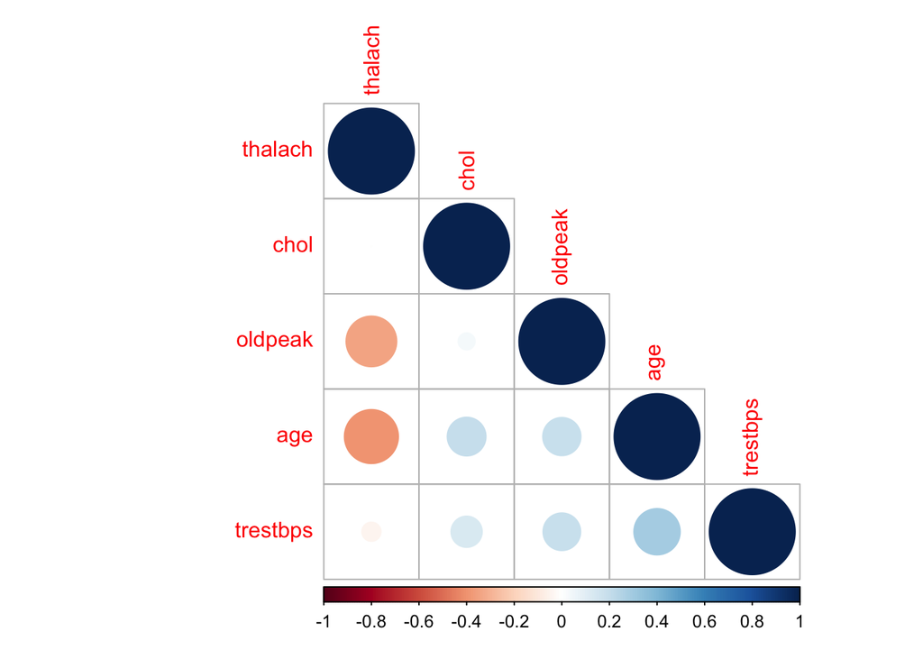

```r
##Looking at correlations between continuous variables

cont_cor <- final_data %>% dplyr::select_if(is.numeric)

corrplot(cor(cont_cor), method = 'circle', type = "lower", order = "hclust")
```

```r
##Looking at concordance between categorical variables

cat_final_data <- final_data %>% dplyr::select_if(is.factor) %>% dplyr::select(-num)

cat_conc <- data.frame(variable = names(cat_final_data), sex = rep(NA, 8), fbs = rep(NA,8), exang = rep(NA,8), cp_clean = rep(NA,8), restecg_clean = rep(NA,8), slope_clean = rep(NA,8), ca_clean = rep(NA,8), thal_clean = rep(NA,8) )

for(i in cat_conc$variable){
  for(j in names(cat_conc[,-1])){

    cat_conc[cat_conc$variable == i, j] <- round(concord_cat(i,j),2)

  }

}

gt(cat_conc, rowname_col = "variable") %>% tab_header(
                              title = "Percentage Concordance between Categorical Features ",
                              subtitle = "Concordance is when both features have the same binary value"
                            ) %>% data_color(
                              columns = vars(sex, fbs,exang, cp_clean, restecg_clean, slope_clean, ca_clean, thal_clean),
                              colors = scales::col_numeric(
                                palette = paletteer::paletteer_d(
                                  palette = "dichromat::LightBluetoDarkBlue_10"
                                ) %>% as.character(),
                                domain = NULL
                              )
                            )
```

Percentage Concordance between Categorical Features

Concordance is when both features have the same binary value

|  | sex | fbs | exang | cp_clean | restecg_clean | slope_clean | ca_clean | thal_clean |
| --- | --- | --- | --- | --- | --- | --- | --- | --- |
| sex | 100.00 | 38.72 | 50.17 | 46.80 | 51.18 | 51.85 | 52.19 | 66.33 |
| fbs | 38.72 | 100.00 | 62.29 | 51.52 | 51.85 | 47.81 | 60.27 | 56.23 |
| exang | 50.17 | 62.29 | 100.00 | 27.95 | 53.87 | 61.95 | 62.29 | 67.00 |
| cp_clean | 46.80 | 51.52 | 27.95 | 100.00 | 43.77 | 38.38 | 37.37 | 32.66 |
| restecg_clean | 51.18 | 51.85 | 53.87 | 43.77 | 100.00 | 57.58 | 55.89 | 51.18 |
| slope_clean | 51.85 | 47.81 | 61.95 | 38.38 | 57.58 | 100.00 | 55.89 | 65.32 |
| ca_clean | 52.19 | 60.27 | 62.29 | 37.37 | 55.89 | 55.89 | 100.00 | 63.64 |
| thal_clean | 66.33 | 56.23 | 67.00 | 32.66 | 51.18 | 65.32 | 63.64 | 100.00 |

From the plots above we can be reasonably sure that none of the continuous variables show significant correlation between them. So we can proceed with all of the continuous variables in our regression specification.

In the case of categorical variables, on average we would expect two independent dichotomous random variables to take the same value on average 50%. From the graph we can see that most of concordance values is in that range. Although some are considerably lower, which is equally bad since it shows negative concordance. Nonetheless, the values are not high or low enough to justify removing them from the regression specification. So we proceed to use all the categorical variables, while noting that some do display concerning levels of concordance.

### Fitting a logistic regression model

As mentioned earlier, before fitting a logistic regression model it is imperative to remove outliers among continuous variables and standardize them according to the method proposed earlier. After these transformations, I proceed to fit a ‘naive’ model with all the features included in the specification. Thereafter, I perform step-wise variable selection using AIC (Akaike Information Criteria). This iterates through the feature set, iteratively adding as well as removing features, and identifies the model with lowest AIC. Below I report the coefficient estimates from both models.

**Click here For Code/Plots**

```r
######################################################################################################################################################################################################
##Logistic regression


#Before Fitting a logistic regression, I remove outliers in continuous variables

int_df <- final_data

for(i in names(int_df)){

  int_df <- var_remove_outliers(i, int_df)


}


#scale the continuous variables by centering and dividing by twice the standard deviation

scaled_final_data <- int_df %>% mutate(across(where(is.numeric), var_scale))

naive_logistic <- glm(data = scaled_final_data, num~. , family=binomial(link="logit"))

#VIF Test for Variance Inflation due to mult-collinearity; values above 5 are a cause for concern
vif(naive_logistic)
```

```
##           age           sex      trestbps          chol           fbs
##      1.435925      1.509871      1.262657      1.200361      1.145521
##       thalach         exang       oldpeak      cp_clean restecg_clean
##      1.363966      1.164090      1.297784      1.218379      1.061983
##   slope_clean      ca_clean    thal_clean
##      1.511257      1.351262      1.323219
```

```r
##Displaying the results

reg_labels<- list(age ~"Age", sex~"Sex", trestbps ~ "Resting Blood Pressure", chol~ "Cholestrol Level", fbs~ "Fasting Blood Sugar",thalach~ "Maximum Heart Rate Achieved", exang~"Exercise Induced Angina", oldpeak~ "Induced ST Depression",  cp_clean ~ "Reported Chest Pain", restecg_clean~"Resting ECG", slope_clean~"Slope of ST Segment", ca_clean ~ "Coloured Vessels", thal_clean~"Thalium Test Result")

tbl_naive_logit <- tbl_regression(naive_logistic, exponentiate = TRUE, label = reg_labels) %>% bold_p() %>% bold_labels()

##Performing Stepwise Selection

step_naive_logit <- stepAIC(naive_logistic, direction = "both", trace = F)

#VIF Test for Variance Inflation due to mult-collinearity; values above 5 are a cause for concern
vif(step_naive_logit)
```

```
##         sex    trestbps        chol     thalach     oldpeak    cp_clean
##    1.417149    1.105678    1.153621    1.212721    1.280703    1.146883
## slope_clean    ca_clean  thal_clean
##    1.465633    1.143395    1.259166
```

```r
reg_labels_2<- list( sex~"Sex", trestbps ~ "Resting Blood Pressure", chol~ "Cholestrol Level",thalach~ "Maximum Heart Rate Achieved",  oldpeak~ "Induced ST Depression",  cp_clean ~ "Reported Chest Pain",  slope_clean~"Slope of ST Segment", ca_clean ~ "Coloured Vessels", thal_clean~"Thalium Test Result")

tbl_step_logit <- tbl_regression(step_naive_logit, exponentiate = T,  label = reg_labels_2)%>%bold_p() %>% bold_labels()

tbl_merge(tbls = list(tbl_naive_logit, tbl_step_logit), tab_spanner = c("**Naive Logit**", "**Step-wise Logit**") ) %>% as_kable_extra(  format = "html",caption = "Results from Logistic Regression Models" ) %>% kable_styling(bootstrap_options = c("striped", "hover", "condensed"), position = "center")
```

Results from Logistic Regression Models

| Characteristic | Naive Logit OR | Naive Logit 95% CI | Naive Logit p-value | Step-wise Logit OR | Step-wise Logit 95% CI | Step-wise Logit p-value |
| --- | --- | --- | --- | --- | --- | --- |
| **Age** | 0.75 | 0.31, 1.78 | 0.5 |  |  |  |
| **Sex** |  |  |  |  |  |  |
| 0 |  |  |  |  |  |  |
| 1 | 3.65 | 1.37, 10.2 | **0.011** | 3.65 | 1.43, 9.82 | **0.008** |
| **Resting Blood Pressure** | 2.06 | 0.97, 4.53 | 0.065 | 1.82 | 0.91, 3.75 | 0.095 |
| **Cholestrol Level** | 2.05 | 0.90, 4.81 | 0.090 | 2.09 | 0.96, 4.68 | 0.066 |
| **Fasting Blood Sugar** |  |  |  |  |  |  |
| 0 |  |  |  |  |  |  |
| 1 | 0.48 | 0.15, 1.46 | 0.2 |  |  |  |
| **Maximum Heart Rate Achieved** | 0.50 | 0.19, 1.28 | 0.2 | 0.48 | 0.19, 1.14 | 0.10 |
| **Exercise Induced Angina** |  |  |  |  |  |  |
| 0 |  |  |  |  |  |  |
| 1 | 1.84 | 0.78, 4.32 | 0.2 |  |  |  |
| **Induced ST Depression** | 1.98 | 0.82, 4.97 | 0.14 | 2.15 | 0.91, 5.25 | 0.085 |
| **Reported Chest Pain** |  |  |  |  |  |  |
| 0 |  |  |  |  |  |  |
| 1 | 0.19 | 0.08, 0.41 | **<0.001** | 0.15 | 0.07, 0.32 | **<0.001** |
| **Resting ECG** |  |  |  |  |  |  |
| 0 |  |  |  |  |  |  |
| 1 | 1.50 | 0.71, 3.19 | 0.3 |  |  |  |
| **Slope of ST Segment** |  |  |  |  |  |  |
| 0 |  |  |  |  |  |  |
| 1 | 2.66 | 1.10, 6.58 | **0.032** | 2.57 | 1.08, 6.18 | **0.033** |
| **Coloured Vessels** |  |  |  |  |  |  |
| 0 |  |  |  |  |  |  |
| 1 | 9.92 | 4.31, 24.5 | **<0.001** | 8.19 | 3.82, 18.7 | **<0.001** |
| **Thalium Test Result** |  |  |  |  |  |  |
| 0 |  |  |  |  |  |  |
| 1 | 3.52 | 1.54, 8.25 | **0.003** | 3.42 | 1.54, 7.75 | **0.003** |

<sup>1</sup> OR = Odds Ratio, CI = Confidence Interval, OR = Odds Ratio, CI = Confidence Interval

The table above shows the coefficients of each feature for two of the regressions specified. Empty cells indicate that the Step-wise selection method dropped the variable. p-Values in bold are < 0.05 and indicate that we can reject the null hypothesis that the effect of the feature is 0 (or 1 in odds-ratio terms).

Using these regression estimates, we can conclude that when conditioned on all available features, an increase in probability of heart disease diagnosis relative to no heart disease diagnosis is associated with a change in category (from 0 to 1) of Colored Vessels, Thalium Test, Slope of ST-Segment, and Sex. The former three implies a symptomatic/abnormal test result whereas the latter implies a change in sex from female to male. Similarly, we can also conclude that a change from reporting no chest pain to reporting chest pain is associated with a decrease in probability of heart disease diagnosis relative to no heart disease diagnosis. I also ran checks to ensures there is no multi-collinearity (correlation among features) inflating the variance of any of the features using the VIF test. All the VIF estimates for features were below 2; any value above 5 is a cause for concern.

## Part 3: Feature Importance using Machine Learning Algorithms

In this section, I will use two machine learning algorithms optimized to predict diagnosis of heart disease. Although predictive power is not of importance for this analysis, these algorithms allow for ranking features based on their relative importance in predicting the response variable. These techniques are also better at identifying non-linear relationships and interactions between features compared to previous techniques. These models deal with the Bias-Variance trade-off much better than normal regression techniques which are constrained by seeking to compute unbiased estimates even at the cost of high variance. Therefore, this appraoch truly exploits machine intelligence with far less intervention from my end in contrast to previous sections.

I shall employ a LASSO Logistic Regression and a Random Forest model with hyperparameter optimization through k-fold cross-validation on the training set. After determinig the model of best fit, I shall rank the features in terms of their relative importance in each model. I also report the performance of both models on a common test set.

### LASSO Logistic Regression

LASSO Logistic Regression is a powerful yet simple machine learning algorithm that is similar to a logistic regression in its basic structure. However, it includes a penalty term hyper-parameter($\lambda$) that works to shrink the coefficient of features to zero to ensure optimal trade-off between bias and variance to ensure maximum predictive power. Thus, it also works as a test of association between features and the response variable. However, the estimated coefficients of features are not very useful or interpretable since by design they are biased (due to the penalty). Therefore I shall not report these coefficient estimates. Nonetheless, there are generalizable, model agnostic technique to determine the relative importance of the features. I am not entirely familiar with the mathematics behind these techniques; I rely on the [vip (Variable Importance Plots) Package](https://cran.r-project.org/web/packages/vip/index.html) in R to produce these figures.

**Click here For Code/Plots**

```r
##Part 3: Variable Importance from Machine Learning
##Lasso logistic



##I train a logistic regression model to predict probaility of heart disease diagnosis and determine the important variables

##Splitting data into training and testing set; i use a 90/10 split since I do not care that much about prediction but want to keep as much data as possible fo training
set.seed(789)

#Normalizing continuous variables
final_data_norm <- final_data %>% mutate(across(where(is.numeric), var_norm ))

final_data_split <- initial_split(final_data_norm, prop = 0.9)

final_data_train <- training(final_data_split)

final_data_test <- testing(final_data_split)

train_iv_matrix <- model.matrix(num~., final_data_train)[,-1]

train_dv <- as.num.fact(final_data_train$num)

##Setting up cross validation

cv_lasso <- cv.glmnet(train_iv_matrix, train_dv, alpha = 1, family ="binomial")

###Specifying best fit model using samllest best cross validated parameter estimate

lasso_model_min <- glmnet(train_iv_matrix, train_dv, alpha = 1, family = "binomial", lambda = cv_lasso$lambda.min  )

lasso_importance <- vi(lasso_model_min)

lasso_importance <- mutate(lasso_importance,
                           Variable = as.factor(Variable)) %>% mutate(Variable = fct_reorder(Variable, (Importance)))

lasso_imp_plot <- ggplot(lasso_importance) +
  geom_col(aes(Variable, Importance, fill = Importance)) +
  scale_y_continuous(breaks = seq(-2,2,0.4))+
  scale_x_discrete(name = "Features", label = c("Reported Chest Pain", "Max Heart Rate Acheived", "Age", "Fasting Blood Sugar","Cholestrol Level", "Induced ST Depression","Resting Blood Pressure" ,"Resting ECG","Exercise Induced Angina" ,"Sex","Slope of ST Segment", "Thalium Test", "Colored Vessels")) +
  coord_flip()+
  ggtitle("Feature Importance from LASSO Logistic Regression")


###Making Predictions
test_iv_matrix <- model.matrix(num~., final_data_test)[,-1]

test_dv <- as.num.fact(final_data_test$num)

lasso_predict <- predict(lasso_model_min, newx = test_iv_matrix)

lasso_prob <- if_else(lasso_predict>0.5,1,0)

mean(lasso_prob == test_dv)
```

```
## [1] 0.7931034
```

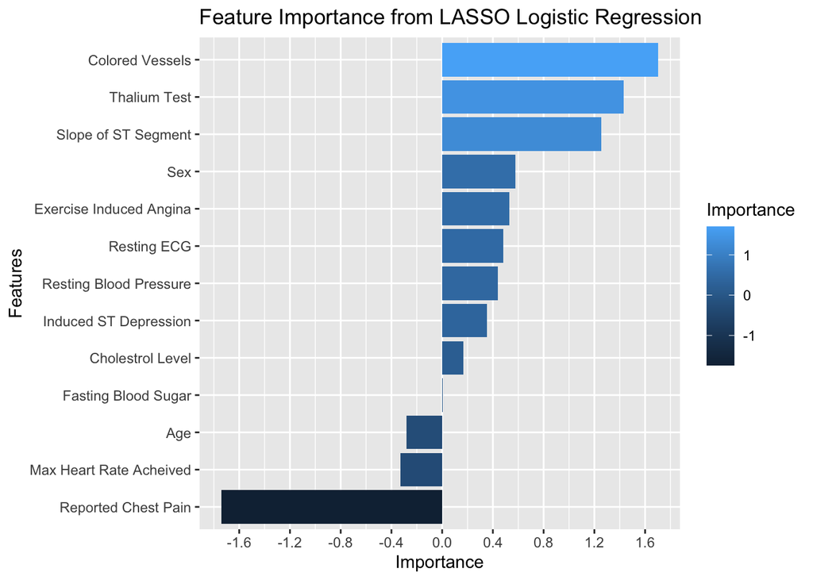

```r
#Lasso has an accuracy of ~80%!!
lasso_imp_plot
```

After hyper-parameter tuning through cross-validation, the LASSO model performs quite well in predicting diagnosis of heart disease. Even without tuning the threshold value (I round values >0.5 to 1 and the rest to zero) the model has a accuracy of almost 80%. More importantly, the model provides an importance estimate for each feature as seen in the plot above. This result seems to be identical to the one from ordinary logistic regression. Colored Vessels, Thalium Test, Slope of ST Segment, and Sex seem to be the most important feature associated with increased chance of heart disease diagnosis; Reported Chest Pain seems to be the most important variable associated with a decreased chance of heart disease diagnosis. The fact that this model entirely agrees with the ordinary logistic regression should not come as a surprise since they both have similar structure, even if different optimization strategies. Nonetheless, this adds greater weight to the conclusions from the earlier section.

### Random Forest Model

Random Forest is an ensemble learning method that has become one of the most, if not the most, popular machine learning technique. They are known to perform very well in classification tasks and provide lots of opportunities for optimization with at least three hyper-parameters that can be tuned. They are excellent at picking up on non-linear relationships and interactions between features that are beyond the scope of linear models. This is the main reason for them being included in this analysis. Through their application I hope to uncover insights that may have eluded earlier techniques.

In applying this method, I do not try to fully optimize it for predictive power. Of the three main hyper-parameters – m_Trys, min_n, and number of trees – I shall try to tune the first two through k-fold cross validation optimizing for AUC. I play around with different number of trees, but do not seek to systematically tune it for performance since our objective is not prediction. Below I report the model accuracy and Feature Importance plots.

**Click here For Code/Plots**

```r
## Random forest

set.seed(1972)

##Copying the same data set as LASSO
forest_train <- final_data_train

forest_test <- final_data_test

forest_cv <- vfold_cv(forest_train, v = 5)

##Prepaing the model spec and prepping; continuous variables have already been normalized

forest_recipe <- recipe(num~., data = forest_train)

forest_recipe_prepped <- forest_recipe  %>% prep(data = forest_train)

forest_juiced <- juice(forest_recipe_prepped)

##Specify the model and engine

forest_tune_spec <- rand_forest(
                                mtry = tune(),
                                trees = 5,
                                min_n = tune()
                                ) %>% set_mode("classification") %>%
                                                                    set_engine("ranger")



##Creating workflow

forest_tune_wf <- workflow() %>% add_recipe(forest_recipe) %>% add_model(forest_tune_spec)

doParallel::registerDoParallel()

##Tuning Hyper parameters mtry and n using cross validation

forest_tune_result <- tune_grid(
                                forest_tune_wf,
                                resamples = forest_cv,
                                grid = 10
)



##Selecting the best model

forest_best <- select_best(forest_tune_result, "roc_auc")

final_forest <- finalize_model(forest_tune_spec, forest_best)

##Identifying important variables

forest_fit <- final_forest %>% set_engine("ranger", importance = "permutation") %>% fit(num~. ,data = forest_juiced)

forest_importance <- vi(forest_fit)

forest_importance <- mutate(forest_importance,
                           Variable = as.factor(Variable)) %>% mutate(Variable = fct_reorder(Variable, (Importance)))

##Plotting

forest_imp_plot <- ggplot(forest_importance) +
  geom_col(aes(Variable, Importance, fill = Importance)) +
  scale_y_continuous()+
  scale_x_discrete(name = "Features", label = c("Exercise Induced Angina" ,"Cholestrol Level","Resting Blood Pressure","Fasting Blood Sugar","Sex", "Age", "Resting ECG","Slope of ST Segment", "Max Heart Rate Acheived" , "Induced ST Depression", "Thalium Test","Reported Chest Pain", "Colored Vessels")) +
  coord_flip()+
  ggtitle("Feature Importance from Random Forest")


##Looking at accuracy

forest_test_predicted <- predict(forest_fit, new_data = forest_test)

sum(as.num.fact(forest_test$num)==forest_test_predicted$.pred_class)/length(forest_test$num)
```

```
## [1] 0.7241379
```

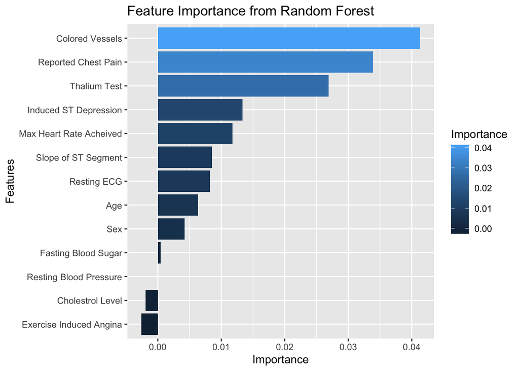

```r
forest_imp_plot
```

After some tuning, I settle on a model that has a prediction accuracy of between 70 and 80%, which is not even better than LASSO.

However, the feature importance plot tells a far more interesting story. First of all, it is important to note that these estimates of importance do not seem stable. In running this code chunk a couple of time I have been shown quite different results even though the seed had remained the same. In fact I am not sure if the results will remain the same when I knit this document. Since the model relies on building decision path through random subsets of variables, this is not be expected. Therefore it’d be risky to generalize. This also suggests that the model needs to be tuned better.

Second, in comparison to the LASSO model, importance is more tightly distributed among the features; the model is not over-reliant on some features like the LASSO model. Although I am not sure if a direct comparison of values of the Importance estimate is warranted, it is still worth noting that the range of Importance is vastly smaller in scale compared to LASSO. This suggests that some features, although not significant by themselves, become important in conjunction with others. This suggests that there maybe significant non-linear effects and interactions between features that is associated with the response variable.

In conclusion it difficult to take the estimates from the Random Forest model seriously given its instability, especially in comparison to LASSO and Logistic model which are far more stable.